# GLM Case Study: Smokers

Alex Reinhart

10/11/2019

This data comes from a study on smoking and the number of deaths due to coronary artery disease. Our goal: compare the risk of death for smokers versus non-smokers at age 40.

Note that the ages here actually represent ten-year observation windows: age 40, for example, actually counts all person-years in the study between ages 35 and 44.

```r
smokers <- read.csv("../data/smokers.csv")
head(smokers)
```

```
##   age deaths    py smoke
## 1  40     32 52407   yes
## 2  40      2 18790    no
## 3  50    104 43248   yes
## 4  50     12 10673    no
## 5  60    206 28612   yes
## 6  60     28  5710    no
```

## Some EDA

Let’s just look at the death rate per person/year at each age, and see what we’re getting into.

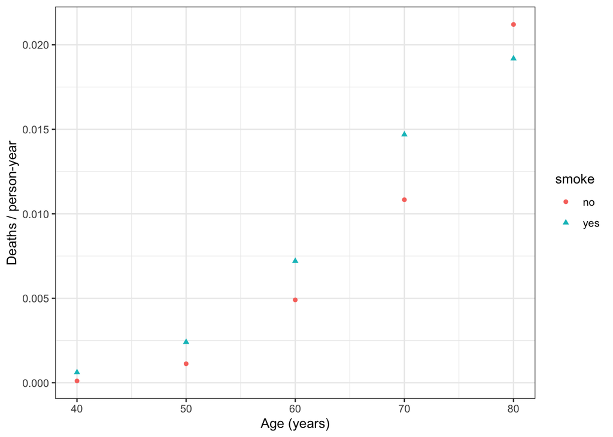

```r
library(ggplot2)

ggplot(smokers, aes(x=age, y=deaths/py, shape=smoke, color=smoke)) +
  geom_point() +
  labs(x="Age (years)", y="Deaths / person-year") +
  theme_bw()
```

So there’s a clear relationship with age, and possibly one with smoking – though maybe it reverses with old age?

Questions:

1. What kind of GLM model should we try here? What distribution, and do we need to specify a specific link or offset?
2. What *plot* can we make to determine what terms to add into the model (i.e. to see if the relationship is linear or not)?

## Model checking plots

If we use a Poisson GLM with age as a covariate and person-years as an offset, plus the standard log link, we’re saying that:

$$\text{deaths} \sim \operatorname{Poisson}(\text{person-years} \times \exp(\beta \times \text{age}))$$

So let’s see if the proportionality seems right: we’d expect a linear relationship between $\log(\text{deaths/person-years})$ and age.

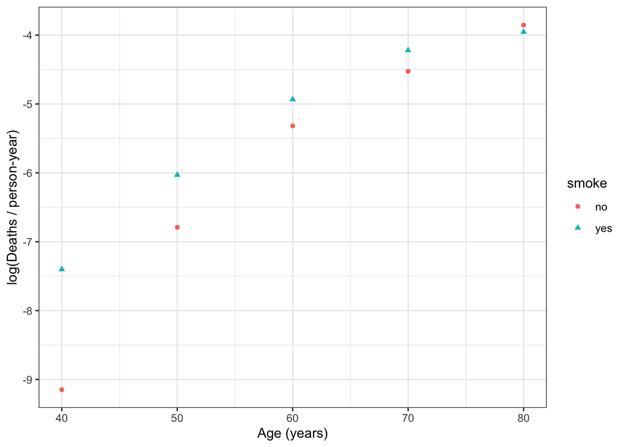

```r
ggplot(smokers, aes(x=age, y=log(deaths/py), shape=smoke, color=smoke)) +
  geom_point() +
  labs(x="Age (years)", y="log(Deaths / person-year)") +
  theme_bw()
```

Uh-oh!

Questions:

1. What terms can we consider adding to the model?
2. What about interactions? Does the plot suggest any interactions?

## Fit a Poisson model

```r
smoke_fit <- glm(deaths ~ smoke * age + smoke * I(age^2) + offset(log(py)),
                 data=smokers, family=poisson(log))
summary(smoke_fit)
```

```
##
## Call:
## glm(formula = deaths ~ smoke * age + smoke * I(age^2) + offset(log(py)),
##     family = poisson(log), data = smokers)
##
## Deviance Residuals:
##        1         2         3         4         5         6         7
##  0.29593  -0.48763  -0.29864   0.25588  -0.04481   0.39375   0.29049
##        8         9        10
## -0.64870  -0.18302   0.26431
##
## Coefficients:
##                     Estimate Std. Error z value Pr(>|z|)
## (Intercept)       -2.149e+01  3.200e+00  -6.716 1.86e-11 ***
## smokeyes           4.405e+00  3.394e+00   1.298  0.19430
## age                4.136e-01  1.005e-01   4.115 3.88e-05 ***
## I(age^2)          -2.421e-03  7.745e-04  -3.126  0.00177 **
## smokeyes:age      -9.637e-02  1.070e-01  -0.901  0.36783
## smokeyes:I(age^2)  5.109e-04  8.279e-04   0.617  0.53713
## ---
## Signif. codes:  0 '***' 0.001 '**' 0.01 '*' 0.05 '.' 0.1 ' ' 1
##
## (Dispersion parameter for poisson family taken to be 1)
##
##     Null deviance: 935.0673  on 9  degrees of freedom
## Residual deviance:   1.2456  on 4  degrees of freedom
## AIC: 68.314
##
## Number of Fisher Scoring iterations: 4
```

Let’s examine the residuals.

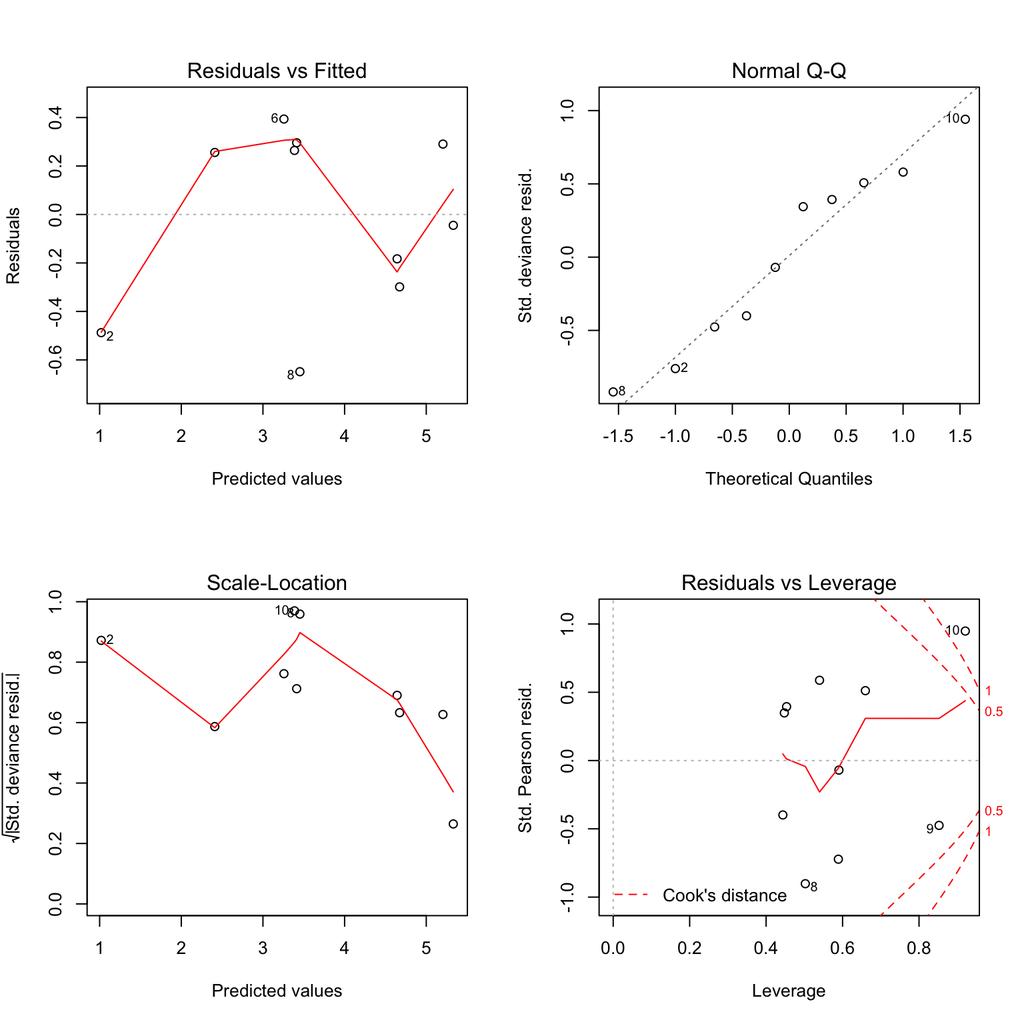

```r
par(mfrow=c(2,2))
plot(smoke_fit)
```

## Answering the substantive question

We’d like to compare the risk of death between smokers and non-smokers at age 40. Let’s start with the naive way of doing this: make predictions.

```r
new_smokers <- data.frame(smoke=c("no", "yes"), age=c(40, 40), py=c(1,1))
preds <- predict(smoke_fit, newdata=new_smokers, se.fit=TRUE, type="response")
preds
```

```
## $fit
##            1            2
## 0.0001474747 0.0005792169
##
## $se.fit
##            1            2
## 6.799084e-05 8.538556e-05
##
## $residual.scale
## [1] 1
```

There are our predictions. For one person-year, the expected mean number of deaths is given; the ratio between smokers and non-smokers is

```r
preds$fit[2] / preds$fit[1]
```

```
##        2
## 3.927567
```

But it’s not easy to make a confidence interval for this. The standard errors are not independent. Let’s more closely examine the regression function – specifically, the ratio between smokers and non-smokers when we set age = 40.

$$\frac{\mathbb{E}[Y \mid \text{age} = 40, \text{smoker}]}{\mathbb{E}[Y \mid \text{age} = 40, \text{non}]}
=
\frac{\exp(\hat \beta_0 + \hat \beta_1 + 40 \hat \beta_2 + 1600 \hat \beta_3 + 40 \hat \beta_4 + 1600 \hat \beta_5)}
{\exp(\hat \beta_0 + 40 \hat \beta_2 + 1600 \hat \beta_3)} = \exp(\hat \beta_1 + 40 \hat \beta_4 + 1600 \hat \beta_5)$$

Hence the ratio can also be calculated as:

```r
coef_vec = c(0, 1, 0, 0, 40, 1600)

exp(sum(coef_vec * coef(smoke_fit)))
```

```
## [1] 3.927567
```

How do we get the variance for this quantity?

We know that $\operatorname{var}(aX) = a^2 \operatorname{var}(X)$. You may also recall that when you take the variance of a sum of random variables, you must account for their covariances (if they’re not independent). The general rule for a vector $c$ and vector $\hat \beta$ is that $\operatorname(var)(c^T \hat \beta) = c^T \operatorname{var}(\hat \beta) c$. So:

```r
t(coef_vec) %*% vcov(smoke_fit) %*% coef_vec
```

```
##           [,1]
## [1,] 0.2342835
```

is the variance (on the log scale, not the scale of the response!). Take the mean plus or minus two standard errors for a Wald confidence interval:

```r
se <- sqrt(t(coef_vec) %*% vcov(smoke_fit) %*% coef_vec)[1,1]

bounds <- sum(coef_vec * coef(smoke_fit)) + c(-2, 2) * se
bounds
```

```
## [1] 0.3999633 2.3360771
```

Finally, we can exponentiate to put our confidence interval back on the right scale:

```r
exp(bounds)
```

```
## [1]  1.49177 10.34059
```

That’s pretty wide.

## Model selection

Suppose we had been interested in making a purely predictive model, rather than comparing rates, and had decided that we’d do model selection to achieve this.

Questions:

1. Why use model selection when we’re making a predictive model? What would it get us?
2. Why not do model selection if we were interested in comparing rates specifically?

Let’s suppose we picked stepwise selection. R supports doing stepwise selection on GLMs.

```r
step_smoke_fit <- step(smoke_fit)
```

```
## Start:  AIC=68.31
## deaths ~ smoke * age + smoke * I(age^2) + offset(log(py))
##
##                  Df Deviance    AIC
## - smoke:I(age^2)  1   1.6354 66.703
## - smoke:age       1   2.0896 67.158
## <none>                1.2456 68.314
##
## Step:  AIC=66.7
## deaths ~ smoke + age + I(age^2) + smoke:age + offset(log(py))
##
##             Df Deviance     AIC
## <none>            1.635  66.703
## - smoke:age  1   12.176  75.243
## - I(age^2)   1   59.893 122.961
```

```r
summary(step_smoke_fit)
```

```
##
## Call:
## glm(formula = deaths ~ smoke + age + I(age^2) + smoke:age + offset(log(py)),
##     family = poisson(log), data = smokers)
##
## Deviance Residuals:
##        1         2         3         4         5         6         7
##  0.43820  -0.83049  -0.27329   0.13404  -0.15265   0.64107   0.23393
##        8         9        10
## -0.41058  -0.05700  -0.01275
##
## Coefficients:
##                Estimate Std. Error z value Pr(>|z|)
## (Intercept)  -1.970e+01  1.253e+00 -15.717  < 2e-16 ***
## smokeyes      2.364e+00  6.562e-01   3.602 0.000316 ***
## age           3.563e-01  3.632e-02   9.810  < 2e-16 ***
## I(age^2)     -1.977e-03  2.737e-04  -7.223 5.08e-13 ***
## smokeyes:age -3.075e-02  9.704e-03  -3.169 0.001528 **
## ---
## Signif. codes:  0 '***' 0.001 '**' 0.01 '*' 0.05 '.' 0.1 ' ' 1
##
## (Dispersion parameter for poisson family taken to be 1)
##
##     Null deviance: 935.0673  on 9  degrees of freedom
## Residual deviance:   1.6354  on 5  degrees of freedom
## AIC: 66.703
##
## Number of Fisher Scoring iterations: 4
```

So we’ve reduced the model by one parameter. What does that do to our confidence interval (warning! don’t do this!)?

```r
coef_vec_step <- c(0, 1, 0, 0, 40)
se_step <- sqrt(t(coef_vec_step) %*% vcov(step_smoke_fit) %*% coef_vec_step)[1,1]

bounds_step <- sum(coef_vec_step * coef(step_smoke_fit)) + c(-2, 2) * se_step
exp(bounds_step)
```

```
## [1] 1.771600 5.446454
```

Question: Why can’t I report this CI as my answer to the substantive question?